# Raster In-Class Work - Key

Rasters are spatial continuous distributions of geospatial data. We have been shown that we an work with data in raster format using either `raster` and working on object directly, or via `dplyr` and using the normal data manipulation routines that we’ve learned for non-spatial data. In this *in class* exercise, you may use both of these techniques to load, manipulate, and display geospatial data.

## The Raw Data

The data for this will be the same Baja California data we showed in the lectures on [points](https://dyerlab.github.io/ENVS-Lectures/spatial/spatial_points/slides.html#1) and [rasters](https://dyerlab.github.io/ENVS-Lectures/spatial/rasters/slides.html#1).

```r
raster_url <- "https://github.com/dyerlab/ENVS-Lectures/raw/master/data/alt_22.tif"
beetle_url <- "https://raw.githubusercontent.com/dyerlab/ENVS-Lectures/master/data/Araptus_Disperal_Bias.csv"
```

## The Questions

1. Load the raster and point data in and crop to an appropriate size to display the locations of the sampling plots and make a label for each site.

```r
library( sf )
library( readr )
library( raster )
library( dplyr )
library( magrittr )
read_csv( beetle_url ) %>%
  st_as_sf( coords=c("Longitude","Latitude"),
            crs=4326) -> beetles
alt <- raster( raster_url )
```

```r
st_bbox( beetles )
```

```
      xmin       ymin       xmax       ymax
-114.29353   23.28550 -109.32700   29.32541
```

```r
alt <- crop( alt, extent( -116, -108, 22, 30))
alt
```

```
class      : RasterLayer
dimensions : 960, 960, 921600  (nrow, ncol, ncell)
resolution : 0.008333333, 0.008333333  (x, y)
extent     : -116, -108, 22, 30  (xmin, xmax, ymin, ymax)
crs        : +proj=longlat +datum=WGS84 +no_defs
source     : memory
names      : alt_22
values     : -202, 2774  (min, max)
```

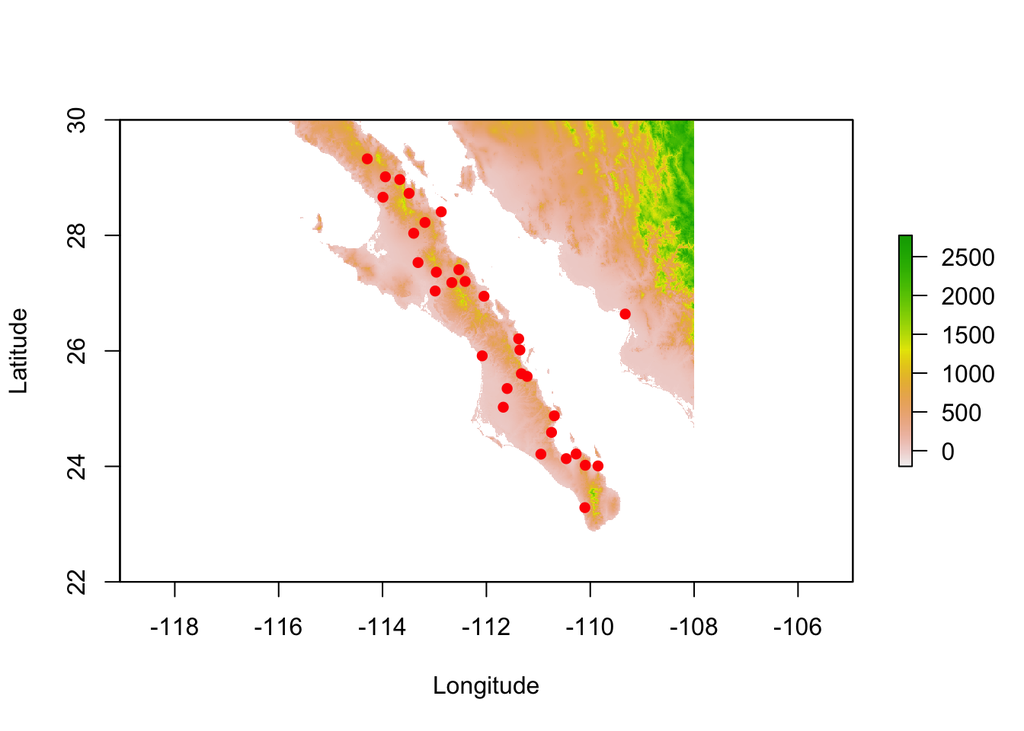

```r
plot( alt, xlab="Longitude", ylab="Latitude" )
plot( beetles, add=TRUE, pch=16, col="red")
```

2. Use the `click()` function to crop the raster and filter the sites to include only the region that is on the peninsula of Baja California. Plot the raster and sites as labels.

```r
plot( alt )
click( alt, xy=TRUE, n=6 ) -> points
```

The points I got were the following (yours may differ). However, since this is an interactive session, I cannot represent it as part of the answer.

```
          x        y value
1 -113.1792 29.85417    NA
2 -108.8792 23.15417    NA
3 -110.0625 22.62083    NA
4 -113.1208 25.49583    NA
5 -115.3625 27.74583    NA
6 -115.7792 29.99583    94
```

```r
points <- data.frame( x = c( -113.1792, -108.8792, -110.0625, -113.1208, -115.3625, -115.7792 ),
                      y = c( 29.85417, 23.15417, 22.62083, 25.49583, 27.74583, 29.99583) )
```

To use it to crop, I’m going to turn it into an `sf` object.

```r
points <- st_as_sf( points, coords=c("x","y"), crs=4326)
points
```

[output not shown]

Now take the cropped raster and mask all the stuff that is not within your points.

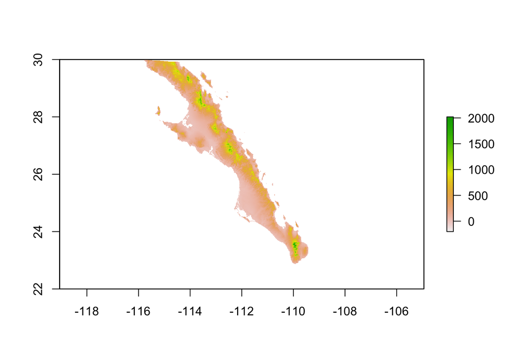

```r
points %>%
  st_union() %>%
  st_convex_hull() -> hull
baja <- mask( alt, as(hull, "Spatial"))
plot( baja )
```

3. The peninsula of Baja California is divided into the States of *Baja California Norte* and *Baja California Sur*. The border between these states is at 28° Latitude. Divide the sample locations into groups based upon which state they are located and plot the average sex ratio of the sample sites partitioned by each site.
4. Is there a relationship between the observed sex ratio and the elevation at that site?